# The Geometry of Archaeological Thought: Analysing discplinary change using word embeddings from conference abstracts

04 June, 2020

# 1 Introduction

BM: The study of disciplinary change traditionally relies on close reading of a large number of publications, manually sorting them into pre-defined categories and making connections between these groups and external influences (e.g. Trigger 1989). These methods are time-consuming and expensive (because they depend on full access to a large library of texts), which limits participation in this aspect of archaeology. Computational approaches to analyzing text that can process many publications quickly to generate topics in a bottom-up fashion offer a new way to investigate disciplinary history. This has the advantage of increasing and diversifying participation in study of the history of archaeology, as well as more comprehensive, systematic, and reproducible analyses of the contents of large number of full-text documents. The methods and data we present here offer empirical basis for what might otherwise be informal claims about the discipline and its history. They are also the type of data that may prompt discussion about the directions the discipline might — or could — take.

BM: In this paper we present a dataset of all available abstracts of papers and posters presented at annual meetings of the Society of American Archaeology. We demonstrate the use of word embeddings, a commonly used computational tool in natural language processing (NLP) and machine learning, as a method to measure, quantify, and compare changes in the way archaeologists write cf. (Garg et al. 2018; Kozlowski, Taddy, and Evans 2019). We present the temporal reference plot as a method for visualizing disciplinary change in archaeology. As a case study, we use these data and methods to explore how archaeologists’ writing about explaining and theorizing the past have changed over time.

# 2 Background

BM: Research into the history of archaeology is often organised into two major phases. An early internalist phase, where the story of development of the field is told with limited reference to the influence of political, social, religious, and economic institutions. In the 1980s an external, critical history phase began, seeking to understand the interactions between archaeological practice and its political, economic and social contexts.

- previous efforts at the history of archaeology (e.g. Bruce Trigger’s book)
- previous efforts at text analysis in archaeology (e.g. bibliometrics, citation networks)
- new phase: we are now in the third phase - computational text analysis
- one promising new method is WE… successful applications of WE in other fields…
- background to Word embeddings

LW & BM: Word embeddings are increasingly being used by researchers in novel ways and have become popular in fields such as digital humanities and computational social science. A word embedding is a set of numbers representing a word that generated from a collection of texts. A word embedding characterizes the meaning a word and can be used to reveal latent semantic relationships between pairs of words, often measured by computing the cosine similarity of two embeddings (Antoniak and Mimno 2018). The general idea is similar to the concept of Principal Component Analysis (PCA) that reduces a multi-dimensional dataset into a small number of new dimensions that typically capture most of the variation in the data. In this case, a word vector is similar to a principal component because it expresses the meaning of the word into a small set of numeric values (e.g. typically 50-250 values). This set is known as the word embedding or word vector, and we visualize vectors on a plot, the distance between two words estimates the similarity between the two words. One of the most interesting and useful qualities of word vectors is that simple arithmetic operations can reveal semantic relationships between words (Mikolov, Yih, and Zweig 2013). For example if we subtract the word vector values for ‘man’ from the word vector values for ‘king’, and add the word vector values for ‘woman’, the resulting vector will be very close to that of ‘queen’, such that we can literally compute ‘king - man + woman’ to get a vector that is approximately the same as ‘queen’.

BM: Word embeddings have been used as evidence in studies of historical change in language and culture (Phillips et al. 2017; Heuser 2017; Kulkarni et al. 2015; Pivovarova, Marjanen, and Zosa 2019). Semantic relations between words in a corpus are captured by the geometry of the vectors, so vectors can be compared with each other to find a word’s nearest neighbors (Giorcelli, Lacetera, and Marinoni 2019). Vectors can be compared across periods to examine the degree of change a word underwent from one-time interval to the next. For example, Hamilton, Leskovec, and Jurafsky (2016) use word embeddings to study semantic change in English over the last 200 years. They visualise how the word ‘gay’ shifted from meaning ‘cheerful’ or ‘frolicsome’ to referring to homosexuality, and the change in ‘broadcast’ from referring to ‘casting out seeds’ to ‘transmitting signals’, with the rise of television and radio in the early 20th century. Yao et al. (2018) generate word embeddings on 99,872 articles from the New York Times, published between January 1990 and July 2016 and their results show major semantic shifts in their words of interest. For example, the word embeddings for the US president names, Obama and Trump, shift from their pre-presidential lives (Obama as a civil rights attorney and university professor; Trump as a real estate developer and TV personality) to the political sphere.

LW: Word embeddings have also been used to track demographic and occupational shifts and gender stereotypes. For example, Garg et al. (2018) explored changes in gender stereotypes and attitudes toward ethnic minorities in the 20th and 21st centuries in the US. They used word embeddings from different sources after 1900, including Google News, Google Books, and the Corpus of Historical American English using the word2vec algorithm and New York Times using the GloVe algorithm. They extracted word embeddings for sets of words representing gender (e.g. he, man, boy, etc.) and ethnicity (e.g. last names such as Li, Wong, Kim), and a set of neutral words, such as adjectives and job titles, serving as indicators for stereotypes and attitudes. They compared the association of word vectors between each set words (gender and ethnic minorities) and neutral words, where the strength of association is calculated by computing average embedding distance. Their results show that jobs such as nurses, dancers, housekeepers have been biased toward women and there is an increase in adjectives for describing women’s competence, such as intelligent, after the women’s movement in the 1960s-1970s, with higher participation rates in jobs. Another bias is the jobs of Asian-Americans which were associated with academic positions, reflecting the stereotype of the model minority, and their adjectives shift from negative words describing outsiders before 1950 to stereotype words about personality traits after 1950, with the growth of the Asian-American population. This study demonstrates a successful use of word embeddings to detect semantic change over time that reveal social biases that correspond to broader sociocultural contexts.

# 3 Methods

```r
saa_data <- readxl::read_excel(here::here("data", "raw-data", "saa-abstracts-tally.xlsx"))
```

```r
# basic stats
library(tidyverse)
abstract_num <- sum(saa_data$number_of_abstracts, na.rm = TRUE)
year_num <- length(which(!is.na(saa_data$number_of_abstracts))) # 41 years

# get all txt files of abstracts
abstract_txt_files <-
  fs::dir_ls(here::here("data/derived-data/"),
             recurse = TRUE,
             regexp = '\\.txt$')
all_txts <- tolower(readtext::readtext(abstract_txt_files))

# total word counts
all_word_counts <- sum(stringi::stri_count_words(all_txts))

# the highest number of abstract
high_abs <- max(saa_data$number_of_abstracts, na.rm = TRUE)
```

LW: The PDFs for the years 1962-1994 contain images of pages, and after 2005 the PDFs are searchable text. We converted the page images from PDF to PNG files using ImageMagick software, and then used optical character recognition to extract text from the PNG files with the Tesseract package (Kay 2007). We obtained an acceptable rate of 95-98% word-level OCR accuracy across the PDFs (Holley 2009). After OCR, we removed punctuation, numbers, and stopwords, such as “the”, “an”, “a”, due to their little or no semantic value for our research question, with the quanteda package (Benoit et al. 2018).

LW: We transformed the cleaned text into a document-feature matrix. This is a rectangular, tabular data structure where one row represents one PDF, and one column represents one word, also known as a feature. The cell values in this matrix are the frequencies of each feature for each PDF. We selected the features that occur at least three times across all PDFs for construction of a feature co-occurrence matrix. To create this matrix we calculated how often each feature appears with another. The co-occurrences are measured within a defined range of surrounding words, known as a window, with the target feature in the middle position and context features before and after it. Here we set the range to five, meaning five words before and five words after the target feature, as our framework for calculating the co-occurrence counts.

LW: We generated the word embedding on the co-occurrence matrix using the GloVe algorithm from the text2vec package for R (Pennington, Socher, and Manning 2014; Selivanov, n.d.). GloVe (Global Vectors) is an unsupervised learning algorithm that creates word vectors to represent semantic regularities and capture relationships between words (Pennington, Socher, and Manning 2014). The general idea is that the multiplied value of the final word vectors for any two words will be equivalent to the logarithm of those words’ probability of co-occurrence. To achieve this, GloVe performs a weighted least squares regression for every word continuously along the text to generate vector values by maximizing the probability of a surrounding word with the occurrence of a center word. GloVe generates two sets of word vectors for each word (i.e. for the word as a center word or a surrounding word), and final word vector is the sum of these two sets of values.

BM: One of the key practical challenges of studying temporal change in word embeddings is aligning the vectors representing the same words across multiple time periods. This is because the stochastic nature of word embeddings algorithms makes them generate representations that always have different coordinate systems and thus one set of embeddings are not directly comparable to another set generated on a different corpus (i.e. from a different time period). Previous work generally follows a two-step pattern: first compute word embeddings in each time slice separately, then find a way to align the word embeddings across time slices. Kim et al. (2014) generated word embeddings for each time period by initializing them with the embeddings from the previous period. Kulkarni et al. (2015) compute a linear transformation of words between any two time slices by solving a n-dimensional least squares problem of k nearest neighbor words (where n is the embedding dimension). Zhang et al. (2016) similarly use a linear transformation between a base and target time slices, and compute the linear transformation using anchor words that does not change meaning between the two time slices (requiring prior knowledge of words that are static). Hamilton, Leskovec, and Jurafsky (2016) solves a n-dimensional Procrustes problem between every two adjacent time slices to perform the alignment. These alignment procedures are complex, and Dubossarsky, Weinshall, and Grossman (2017) show that they suffer from biases and produce spurious results. Dubossarsky et al. (2019) show that an alternative method, temporal referencing, avoids these concerns about previous alignment methods using a radically simpler procedure. Temporal referencing combines all time-specific corpora into one corpus, and generates word embeddings on this full corpus. Before generating the embeddings, they first replace each instance of the target word with a time-specific token. For example, the word ‘theory’ is replaced by the time-specific token ‘theory (1970-1980)’ in the meeting abstracts from the years 1970-1980, and ‘theory (1980-1990)’ in the meeting abstracts from the years 1980-1990, and so on for each time slice. Then a single space is generated that contains a vector for each time-specific token, and the coordinates of the background, or context, words remain the same for each time slice, with no need for alignment. Besides the advantage of avoiding alignment, this temporal referencing method lowers data requirements (because context words are collapsed, and thus shared across time slices) and is suitable for smaller corpora, producing smooth change values without millions of words. A key assumption of this approach, as with the alignment methods, is that the semantics of the context words stay relatively stable over time.

BM: Once the embeddings had been generated, we visualized the word vector values to explore the historical trends of word meanings in archaeology. We first subset the corpus to identify the words that are semantically similar to our target word using the cosine distance measure on pairs of word vectors. These similar words become the context words that map the semantic space that our target word moves through over time. Then we used the t-Distributed Stochastic Neighbor Embedding (t-SNE) method (Maaten and Hinton 2008) for constructing a two dimensional embedding of the word vectors to reduce the high dimensionality of the word vectors so they can be projected on a scatter plot. t-SNE is a visualisation method that retaining the local structure of the data while also revealing some important global structure (such as clusters). This is useful for placing similar words close together on the plot, while maximizing the distance between dissimilar words. While t-SNE is highly flexible, and can often find structure where other dimensionality-reduction algorithms, such as PCA, cannot (Balamurali and Melkumyan 2016), it can produce plots that are difficult to interpret, and some elements can be highly sensitive to different hyperparameter settings, for example the size of the clusters and inter-cluster distances (Wattenberg, Viégas, and Johnson 2016). A key limitation is that because t-SNE is non-linear (compared to PCA which is a linear transformation) and adapts to the underlying data, performing different transformations on different regions of the data, t-SNE plots are not easily interpretable in terms of the axes/units of the original, high-dimensional data.

```r
# load the functions for computing temporal referencing and drawing plots
source(here::here("code/006-temp-ref-functions.R"))
```

```r
# run the functions for computing temporal referencing and drawing plots
source(here::here("code/006-temp-ref-scripts.R"))
```

[output not shown]

[output not shown]

[output not shown]

[output not shown]

[output not shown]

[output not shown]

[output not shown]

[output not shown]

[output not shown]

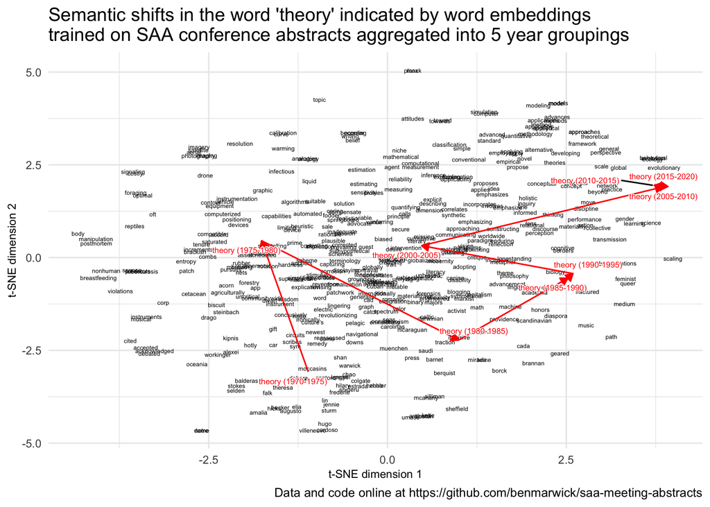

```r
knitr::include_graphics(here::here("figures/tr-plot-target-word-is-theory-5-by-year-intervals.png"))
```

– word frequency time series - TR plots

# 4 Discussion

# 5 Conclusion

# 6 Acknowledgements

# 7 References

Antoniak, Maria, and David Mimno. 2018. “Evaluating the Stability of Embedding-Based Word Similarities.” *Transactions of the Association for Computational Linguistics* 6: 107–19.

Balamurali, Mehala, and Arman Melkumyan. 2016. “T-Sne Based Visualisation and Clustering of Geological Domain.” In *International Conference on Neural Information Processing*, 565–72. Springer.

Benoit, Kenneth, Kohei Watanabe, Haiyan Wang, Paul Nulty, Adam Obeng, Stefan Müller, and Akitaka Matsuo. 2018. “Quanteda: An R Package for the Quantitative Analysis of Textual Data.” *Journal of Open Source Software* 3 (30): 774.

Dubossarsky, Haim, Simon Hengchen, Nina Tahmasebi, and Dominik Schlechtweg. 2019. “Time-Out: Temporal Referencing for Robust Modeling of Lexical Semantic Change.” *arXiv Preprint arXiv:1906.01688*.

Dubossarsky, Haim, Daphna Weinshall, and Eitan Grossman. 2017. “Outta Control: Laws of Semantic Change and Inherent Biases in Word Representation Models.” In *Proceedings of the 2017 Conference on Empirical Methods in Natural Language Processing*, 1136–45.

Garg, Nikhil, Londa Schiebinger, Dan Jurafsky, and James Zou. 2018. “Word Embeddings Quantify 100 Years of Gender and Ethnic Stereotypes.” *Proceedings of the National Academy of Sciences* 115 (16): E3635–E3644.

Giorcelli, Michela, Nicola Lacetera, and Astrid Marinoni. 2019. “Does Scientific Progress Affect Culture? A Digital Text Analysis.” National Bureau of Economic Research.

Hamilton, William L, Jure Leskovec, and Dan Jurafsky. 2016. “Diachronic Word Embeddings Reveal Statistical Laws of Semantic Change.” In *Proceedings of the 54th Annual Meeting of the Association for Computational Linguistics (Volume 1: Long Papers)*, 1489–1501.

Heuser, Ryan James. 2017. “Word Vectors in the Eighteenth Century.” In *Digital Humanities, Montreal, Canada, August 8-11, 2017*.

Holley, Rose. 2009. “How Good Can It Get? Analysing and Improving Ocr Accuracy in Large Scale Historic Newspaper Digitisation Programs.” *D-Lib Magazine* 15 (3/4).

Kay, Anthony. 2007. “Tesseract: An Open-Source Optical Character Recognition Engine.” *Linux Journal* 2007 (159): 2.

Kim, Yoon, Yi-I Chiu, Kentaro Hanaki, Darshan Hegde, and Slav Petrov. 2014. “Temporal Analysis of Language Through Neural Language Models.” *arXiv Preprint arXiv:1405.3515*.

Kozlowski, Austin C, Matt Taddy, and James A Evans. 2019. “The Geometry of Culture: Analyzing the Meanings of Class Through Word Embeddings.” *American Sociological Review* 84 (5): 905–49.

Kulkarni, Vivek, Rami Al-Rfou, Bryan Perozzi, and Steven Skiena. 2015. “Statistically Significant Detection of Linguistic Change.” In *Proceedings of the 24th International Conference on World Wide Web*, 625–35.

Maaten, Laurens van der, and Geoffrey Hinton. 2008. “Visualizing Data Using T-Sne.” *Journal of Machine Learning Research* 9 (Nov): 2579–2605.

Mikolov, Tomáš, Wen-tau Yih, and Geoffrey Zweig. 2013. “Linguistic Regularities in Continuous Space Word Representations.” In *Proceedings of the 2013 Conference of the North American Chapter of the Association for Computational Linguistics: Human Language Technologies*, 746–51.

Pennington, Jeffrey, Richard Socher, and Christopher D Manning. 2014. “Glove: Global Vectors for Word Representation.” In *Proceedings of the 2014 Conference on Empirical Methods in Natural Language Processing (Emnlp)*, 1532–43.

Phillips, Lawrence, Kyle Shaffer, Dustin Arendt, Nathan Hodas, and Svitlana Volkova. 2017. “Intrinsic and Extrinsic Evaluation of Spatiotemporal Text Representations in Twitter Streams.” In *Proceedings of the 2nd Workshop on Representation Learning for Nlp*, 201–10.

Pivovarova, Lidia, Jani Marjanen, and Elaine Zosa. 2019. “Word Clustering for Historical Newspapers Analysis.” *RANLP 2019*, 3.

Selivanov, Dmitriy. n.d. “Text2vec: Modern Text Mining Framework for R.” *R Package Version 0.4. 0*.

Trigger, Bruce G. 1989. *A History of Archaeological Thought*. Cambridge University Press.

Wattenberg, Martin, Fernanda Viégas, and Ian Johnson. 2016. “How to Use T-Sne Effectively.” *Distill*. https://doi.org/10.23915/distill.00002.

Yao, Zijun, Yifan Sun, Weicong Ding, Nikhil Rao, and Hui Xiong. 2018. “Dynamic Word Embeddings for Evolving Semantic Discovery.” In *Proceedings of the Eleventh Acm International Conference on Web Search and Data Mining*, 673–81.

Zhang, Yating, Adam Jatowt, Sourav S Bhowmick, and Katsumi Tanaka. 2016. “The Past Is Not a Foreign Country: Detecting Semantically Similar Terms Across Time.” *IEEE Transactions on Knowledge and Data Engineering* 28 (10): 2793–2807.